# Fairness in Housing Appraisal: Predicting Housing Prices in Cook County

**By:** Ava Haddock & Victor Cornejo

## Continuing

In the first part of this project, we performed some basic exploratory data analysis (EDA), laying out the thought process that leads to certain modeling decisions. Then, we added a few new features to the dataset, cleaning the data as well in the process.

In this part, we specified and fitted a linear model to a few features of the housing data to predict housing prices. We analyzed the error of the model and brainstormed ways to improve the model's performance. Finally, we delved deeper into the implications of predictive modeling within the Cook County Assessor's Office (CCAO) case study, especially because statistical modeling is how the CCAO valuates properties. Given the history of racial discrimination in housing policy and property taxation in Cook County, we considered the impacts of our modeling results as we worked through this project - and thought about what fairness might mean to property owners in Cook County.

```python
import numpy as np

import pandas as pd
from pandas.api.types import CategoricalDtype

%matplotlib inline
import matplotlib.pyplot as plt
import seaborn as sns
from sklearn import linear_model as lm

import warnings
warnings.filterwarnings("ignore")

import zipfile
import os

from ds100_utils import run_linear_regression_test

# Plot settings
plt.rcParams['figure.figsize'] = (12, 9)
plt.rcParams['font.size'] = 12
```

Loading the training and test data.

```python
with zipfile.ZipFile('cook_county_data.zip') as item:
    item.extractall()
```

```python
training_data = pd.read_csv("cook_county_train.csv", index_col='Unnamed: 0')
test_data = pd.read_csv("cook_county_test.csv", index_col='Unnamed: 0')
```

As a good sanity check, we verified that the data shape matched the description.

```python
# 204792 observations and 62 features in training data
assert training_data.shape == (204792, 62)
# 68264 observations and 61 features in test data
assert test_data.shape == (68264, 61)
# Sale Price is provided in the training data
assert 'Sale Price' in training_data.columns.values
# Sale Price is hidden in the test data
assert 'Sale Price' not in test_data.columns.values
```

Reminding ourselves of the data available to us in the Cook County dataset.

```python
training_data.columns.values
```

```
array(['PIN', 'Property Class', 'Neighborhood Code', 'Land Square Feet',
       'Town Code', 'Apartments', 'Wall Material', 'Roof Material',
       'Basement', 'Basement Finish', 'Central Heating', 'Other Heating',
       'Central Air', 'Fireplaces', 'Attic Type', 'Attic Finish',
       'Design Plan', 'Cathedral Ceiling', 'Construction Quality',
       'Site Desirability', 'Garage 1 Size', 'Garage 1 Material',
       'Garage 1 Attachment', 'Garage 1 Area', 'Garage 2 Size',
       'Garage 2 Material', 'Garage 2 Attachment', 'Garage 2 Area',
       'Porch', 'Other Improvements', 'Building Square Feet',
       'Repair Condition', 'Multi Code', 'Number of Commercial Units',
       'Estimate (Land)', 'Estimate (Building)', 'Deed No.', 'Sale Price',
       'Longitude', 'Latitude', 'Census Tract',
       'Multi Property Indicator', 'Modeling Group', 'Age', 'Use',
       "O'Hare Noise", 'Floodplain', 'Road Proximity', 'Sale Year',
       'Sale Quarter', 'Sale Half-Year', 'Sale Quarter of Year',
       'Sale Month of Year', 'Sale Half of Year', 'Most Recent Sale',
       'Age Decade', 'Pure Market Filter', 'Garage Indicator',
       'Neigborhood Code (mapping)', 'Town and Neighborhood',
       'Description', 'Lot Size'], dtype=object)
```

### How much is a house worth?

**And who might be interested in an answer to this question?**

Well, a house's worth depends largely on who is valuing it. A homeowner or real estate agent, for example, will want to maximize the value of a property in order to sell it for a profit. A potential buyer, on the other hand, will want to minimize the value in order to get a good deal. The government also has a vested interest in the value of a property, as it will be taxed accordingly. And finally, banks will also want to know the value of a property in order to lend money to the homeowner.

However, an assessment process that systematically overvalues inexpensive properties and undervalues expensive properties is unfair. Because it means that the homeowner will be paying more in taxes than they should be, whereas the homeowner of an expensive property will be paying less than they should be...

## The CCAO Dataset

The dataset we worked with came from the Cook County Assessor’s Office (CCAO) in Illinois, a government institution that determines property taxes across most of Chicago’s metropolitan area and its nearby suburbs. In the United States, all property owners are required to pay property taxes, which are then used to fund public services including education, road maintenance, and sanitation. These property tax assessments are based on property values estimated using statistical models that consider multiple factors, such as real estate value and construction cost.

This system, however, is not without flaws. In late 2017, a lawsuit was filed against the office of Cook County Assessor Joseph Berrios for producing “[racially discriminatory assessments and taxes](https://www.chicagotribune.com/politics/ct-cook-county-board-assessor-berrios-met-20170718-story.html)." The lawsuit included claims that the assessor’s office undervalued high-priced homes and overvalued low-priced homes, creating a visible divide along racial lines: Wealthy homeowners, who were typically white, [paid less in property taxes](https://www.clccrul.org/bpnc-v-berrios-facts?rq=berrios), whereas [working-class, non-white homeowners paid more](https://www.chicagotribune.com/news/breaking/ct-cook-county-assessor-berrios-sued-met-20171214-story.html).

The Chicago Tribune's four-part series, "[The Tax Divide](https://www.chicagotribune.com/investigations/ct-tax-divide-investigation-20180425-storygallery.html)", delves into how this was uncovered: After "compiling and analyzing more than 100 million property tax records from the years 2003 through 2015, along with thousands of pages of documents, then vetting the findings with top experts in the field," they discovered that "residential assessments had been so far off the mark for so many years." More about their investigation [here](https://apps.chicagotribune.com/news/watchdog/cook-county-property-tax-divide/assessments.html).

The central problems with the earlier property tax system in Cook County were that it was unfair and regressive, and that it placed a disproportionate burden on homeowners. The primary causes of these problems were that the system was based on assessed values that were not accurate, and that it was not transparent.

In addition to being regressive, the Cook County property tax system disproportionately burdened non-white property owners because it is based on the assessed value of the property, rather than the actual market value. This means that properties in predominantly non-white neighborhoods are assessed at lower values than properties in predominantly white neighborhoods, resulting in higher tax rates for non-white property owners.

## Splitting the Data

We split the data set into a training set and test set. We used the training set to fit our model's parameters, and we used the test set to estimate how well our model performed on unseen data drawn from the same distribution. If we used all the data to fit our model, we would not have a way to estimate model performance on **unseen data**.

Since the sale prices for `cook_county_test.csv` weren't provided to us, we constructed our own test set for which we knew the outputs.

Here, we completed the function `train_test_split` that split `data` into two smaller DataFrames named `train` and `test`. We let `train` contain 80% of the data, and let `test` contain the remaining 20% of the data.

To do this, we created two NumPy arrays named `train_indices` and `test_indices`. `train_indices` contained a *random* 80% of the indices in `full_data`, and `test_indices` contained the remaining 20% of the indices. Then, we used these arrays to index into `full_data` to create our final `train` and `test` DataFrames.

```python
# This makes the train-test split in this section reproducible across different runs
# of the notebook. You do not need this line to run train_test_split in general

# DO NOT CHANGE THIS LINE
np.random.seed(1337)
# DO NOT CHANGE THIS LINE

def train_test_split(data):
    data_len = data.shape[0]
    shuffled_indices = np.random.permutation(data_len)
    train_indices = shuffled_indices[:int(data_len * 0.8)]
    test_indices = shuffled_indices[int(data_len * 0.8):]
    train = data.iloc[train_indices]
    test = data.iloc[test_indices]
    return train, test
train, test = train_test_split(training_data)
```

Then we fitted our updated linear regression model using the ordinary least squares estimator. We started off with something simple by using only 2 features: the **number of bedrooms** in the household and the **log-transformed total area covered by the building** (in square feet).

Considering the following expression for our 1st linear model that contained one of the features:

$$ \text{Log Sale Price} = \theta_0 + \theta_1 \cdot (\text{Bedrooms}) $$

In parallel, we also considered a 2nd model that contained both features:

$$ \text{Log Sale Price} = \theta_0 + \theta_1 \cdot (\text{Bedrooms}) + \theta_2 \cdot (\text{Log Building Square Feet}) $$

## Pipeline

In the first part we wrote a few functions that added features to the dataset. Instead of manually calling each function to add these features to the dataset, we encapsulated all of this feature engineering into one "pipeline" function. This because defining and using a pipeline reduces all the feature engineering to just one function call and ensures that the same transformations are applied to all data.

The following function `process_data_gm`, takes in a dataframe `data`, a list `pipeline_functions` containing 3-element tuples `(function, arguments, keyword_arguments)` that was called on `data` in the pipeline, and the label `prediction_col` that represented the column of our target variable (`Sale Price` in this case). It returned two NumPy arrays: `X`, which was our design matrix, and `y` which was the vector containing the observed data.

```python
from feature_func import *    # imports functions from Project 1A
# run this cell to define process_data_gm and select_columns

def process_data_gm(data, pipeline_functions, prediction_col):
    """Process the data for a guided model."""
    for function, arguments, keyword_arguments in pipeline_functions:
        if keyword_arguments and (not arguments):
            data = data.pipe(function, **keyword_arguments)
        elif (not keyword_arguments) and (arguments):
            data = data.pipe(function, *arguments)
        else:
            data = data.pipe(function)
    X = data.drop(columns=[prediction_col]).to_numpy()
    y = data.loc[:, prediction_col].to_numpy()
    return X, y
```

```python
def select_columns(data, *columns):
    """Select only columns passed as arguments."""
    return data.loc[:, columns]

def log_transform(data, col):
    """Add the log transformation of a column to the data frame"""
    data['Log ' + col] = np.log(data[col])
    return data
```

To prepare the training and validation data for the two models we proposed above, we used the following 2 cells to reload a fresh dataset from scratch and ran them through the following preprocessing steps for each model:

- Performed a `train_test_split` on the original dataset. Let 80% of the set be training data and 20% of the set be validation data. **Even though we are splitting our dataset into training and validation sets.**
- For both the training and validation set,
  1. Removed outliers in `Sale Price` by so that we were considering households with a price that was strictly greater than 499 dollars (i.e., greater than or equal to 500 dollars).
  2. Applied log transformations to `Sale Price` and the `Building Square Feet` columns to create 2 new columns `Log Sale Price` and `Log Building Square Feet`.
  3. Extracted the total number of bedrooms into a new column `Bedrooms` from the `Description` column.
  4. Selected the columns `Log Sale Price` and `Bedrooms` (and `Log Building Square Feet` as well if this is the 2nd model).
  5. Returned the design matrix $X$ and the observed vector $y$.

We assigned the final training data and validation data for both models to the following set of variables:

- 1st Model: `X_train_m1`, `y_train_m1`, `X_test_m1`, `y_test_m1`
- 2nd Model: `X_train_m2`, `y_train_m2`, `X_test_m2`, `y_test_m2`

```python
# Reload the data
full_data = pd.read_csv("cook_county_train.csv")

# Process the data using the pipeline for the first model
np.random.seed(1337)
train_m1, test_m1 = train_test_split(full_data)

m1_pipelines = [
    (remove_outliers, None, {
        'variable': 'Sale Price',
        'lower': 499,
    }),
    (log_transform, None, {'col': 'Sale Price'}),
    (add_total_bedrooms, None, None),
    (select_columns, ['Log Sale Price', 'Bedrooms'], None)
]


X_train_m1, y_train_m1 = process_data_gm(train_m1, m1_pipelines, 'Log Sale Price')
X_test_m1, y_test_m1 = process_data_gm(test_m1, m1_pipelines, 'Log Sale Price')
```

```python
np.random.seed(1337)

# Process the data using the pipeline for the second model
train_m2, test_m2 = train_test_split(full_data)

m2_pipelines = [
    (remove_outliers, None, {
        'variable': 'Sale Price',
        'lower': 499,
    }),
    (log_transform, None, {'col': 'Sale Price'}),
    (log_transform, None, {'col': 'Building Square Feet'}),
    (add_total_bedrooms, None, None),
    (select_columns, ['Log Sale Price', 'Bedrooms', 'Log Building Square Feet'], None)
]
X_train_m2, y_train_m2 = process_data_gm(train_m2, m2_pipelines, 'Log Sale Price')
X_test_m2, y_test_m2 = process_data_gm(test_m2, m2_pipelines, 'Log Sale Price')
```

## Regression

Finally!

We first initialized a [`sklearn.linear_model.LinearRegression`](https://scikit-learn.org/stable/modules/generated/sklearn.linear_model.LinearRegression.html) object for both of our models. We then set the `fit_intercept = True` to ensure that the linear model had a non-zero intercept (i.e., a bias term).

```python
linear_model_m1 = lm.LinearRegression(fit_intercept=True)
linear_model_m2 = lm.LinearRegression(fit_intercept=True)
```

To fit our linear regression model, we computed the fitted values of `Log Sale Price` over the training data, and the predicted values of `Log Sale Price` for the testing data.

We reassigned the predicted values from both of our models on the training and testing set to the following variables:

- 1st Model: prediction on training set: `y_fitted_m1`, prediction on testing set: `y_predicted_m1`
- 2nd Model: prediction on training set: `y_fitted_m2`, prediction on testing set: `y_predicted_m2`

```python
# Fit the 1st model
# Compute the fitted and predicted values of Log Sale Price for 1st model
y_fitted_m1 = linear_model_m1.fit(X_train_m1, y_train_m1).predict(X_train_m1)
y_predicted_m1 = linear_model_m1.predict(X_test_m1)

# Fit the 2nd model
# Compute the fitted and predicted values of Log Sale Price for 2nd model
y_fitted_m2 = linear_model_m2.fit(X_train_m2, y_train_m2).predict(X_train_m2)
y_predicted_m2 = linear_model_m2.predict(X_test_m2)
```

## Analysis

We then compared the performance of our two regression models using the Root Mean Squared Error function.

$$RMSE = \sqrt{\dfrac{\sum_{\text{houses in test set}}(\text{actual price for house} - \text{predicted price for house})^2}{\text{number of of houses}}}$$

The function is provided below.

```python
def rmse(predicted, actual):
    """
    Calculates RMSE from actual and predicted values
    Input:
      predicted (1D array): vector of predicted/fitted values
      actual (1D array): vector of actual values
    Output:
      a float, the root-mean square error
    """
    return np.sqrt(np.mean((actual - predicted)**2))
```

We used our `rmse` function to calculate the training error and test error for both models.

Then, assigned the error from both of our models to the following variables:

- 1st model: `training_error_m1`, `test_error_m1`
- 2nd model: `training_error_m2`, `test_error_m2`

Since the target variable we are working with is log-transformed, it could also be beneficial to transform it back to its original form so we would have more context on how our model was performing when compared to actual housing prices.

We then assigned the error on the "de-log-transformed" sale price from both of our models to the following variables:

- 1st model: `training_error_m1_delog`, `test_error_m1_delog`
- 2nd model: `training_error_m2_delog`, `test_error_m2_delog`

```python
# Training and test errors for the 1st model
training_error_m1 = rmse(y_fitted_m1, y_train_m1)
test_error_m1 = rmse(y_predicted_m1, y_test_m1)

# Training and test errors for the 1st model (in its original values before the log transform)
training_error_m1_delog =  rmse(np.exp(y_fitted_m1), np.exp(y_train_m1))
test_error_m1_delog = rmse(np.exp(y_predicted_m1), np.exp(y_test_m1))


# Training and test errors for the 2nd model
training_error_m2 = rmse(y_fitted_m2, y_train_m2)
test_error_m2 = rmse(y_predicted_m2, y_test_m2)


# Training and test errors for the 2nd model (in its original values before the log transform)
training_error_m2_delog = rmse(np.exp(y_fitted_m2), np.exp(y_train_m2))
test_error_m2_delog = rmse(np.exp(y_predicted_m2), np.exp(y_test_m2))

print("1st Model\nTraining RMSE: {}\nTest RMSE: {}\n".format(training_error_m1, test_error_m1))
print("1st Model (no log transform)\nTraining RMSE: {}\nTest RMSE: {}\n".format(training_error_m1_delog, test_error_m1_delog))
print("2nd Model\nTraining RMSE: {}\nTest RMSE: {}\n".format(training_error_m2, test_error_m2))
print("2nd Model (no log transform)\nTraining RMSE: {}\nTest RMSE: {}\n".format(training_error_m2_delog, test_error_m2_delog))
```

```
1st Model
Training RMSE: 0.9025651719699077
Test RMSE: 0.9068644732045896

1st Model (no log transform)
Training RMSE: 382697.78149699024
Test RMSE: 310679.2486611569

2nd Model
Training RMSE: 0.8042009333446841
Test RMSE: 0.8113963052434995

2nd Model (no log transform)
Training RMSE: 325716.40819160367
Test RMSE: 254880.42228506133
```

## Comparisson

We then compared the actual parameters ($\theta_0$ and $\theta_1$) from both of our models. As a quick reminder,

for the 1st model, $$ \text{Log Sale Price} = \theta_0 + \theta_1 \cdot (\text{Bedrooms}) $$

for the 2nd model, $$ \text{Log Sale Price} = \theta_0 + \theta_1 \cdot (\text{Bedrooms}) + \theta_2 \cdot (\text{Log Building Square Feet}) $$

```python
# Parameters from 1st model
theta0_m1 = linear_model_m1.intercept_
theta1_m1 = linear_model_m1.coef_[0]

# Parameters from 2nd model
theta0_m2 = linear_model_m2.intercept_
theta1_m2, theta2_m2 = linear_model_m2.coef_

print("1st Model\nθ0: {}\nθ1: {}".format(theta0_m1, theta1_m1))
print("2nd Model\nθ0: {}\nθ1: {}\nθ2: {}".format(theta0_m2, theta1_m2, theta2_m2))
```

```
1st Model
θ0: 10.571725401040084
θ1: 0.4969197463141442
2nd Model
θ0: 1.9339633173823696
θ1: -0.030647249803554506
θ2: 1.4170991378689644
```

## Performance

A way we attempted to understand the performance of our model was through a plot of the model the residuals versus the observations.

We plotted the residuals from predicting `Log Sale Price` using **only the 2nd model** against the original `Log Sale Price` for the **test data**. We also ensured that the dot size and opacity in the scatter plot were set appropriately to reduce the impact of overplotting.

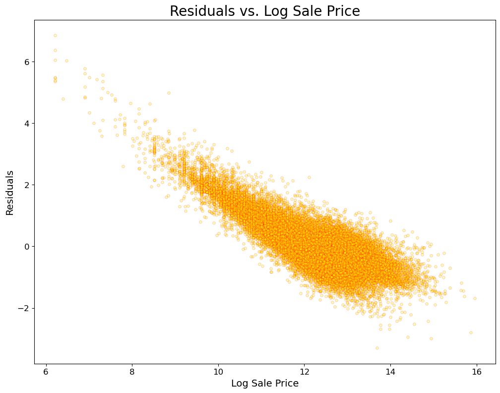

```python
plt.scatter(y_test_m2, y_predicted_m2 - y_test_m2, s=15, alpha=0.3, color='yellow', edgecolors='red', linewidths=0.5 )
plt.xlabel('Log Sale Price', fontsize=14)
plt.ylabel('Residuals', fontsize=14)
plt.title("Residuals vs. Log Sale Price", fontsize=20)
```

### Observation!

Based on the structure we saw in this plot, this model seems like a *regressive* taxation one...

## A New Model

Just as in our previous model, we encapsulated as much of our workflow into functions as possible. We tried to select better features and define our own feature engineering pipeline inside the function `process_data_fm` below.

To evaluate our model, we started by defining a linear regression model. Then, we processed training data using our `process_data_fm`, fitting the model with this training data, and computing the training RMSE. Then, we processed some test data with our `process_data_fm`, using the model to predict `Log Sale Price` for the test data, transforming the predicted and original log values back into their original forms (by using `delog`), and computing the test RMSE.

```python
cook_data = pd.read_csv("cook_county_train.csv")
cook_data.columns.values
```

```
array(['Unnamed: 0', 'PIN', 'Property Class', 'Neighborhood Code',
       'Land Square Feet', 'Town Code', 'Apartments', 'Wall Material',
       'Roof Material', 'Basement', 'Basement Finish', 'Central Heating',
       'Other Heating', 'Central Air', 'Fireplaces', 'Attic Type',
       'Attic Finish', 'Design Plan', 'Cathedral Ceiling',
       'Construction Quality', 'Site Desirability', 'Garage 1 Size',
       'Garage 1 Material', 'Garage 1 Attachment', 'Garage 1 Area',
       'Garage 2 Size', 'Garage 2 Material', 'Garage 2 Attachment',
       'Garage 2 Area', 'Porch', 'Other Improvements',
       'Building Square Feet', 'Repair Condition', 'Multi Code',
       'Number of Commercial Units', 'Estimate (Land)',
       'Estimate (Building)', 'Deed No.', 'Sale Price', 'Longitude',
       'Latitude', 'Census Tract', 'Multi Property Indicator',
       'Modeling Group', 'Age', 'Use', "O'Hare Noise", 'Floodplain',
       'Road Proximity', 'Sale Year', 'Sale Quarter', 'Sale Half-Year',
       'Sale Quarter of Year', 'Sale Month of Year', 'Sale Half of Year',
       'Most Recent Sale', 'Age Decade', 'Pure Market Filter',
       'Garage Indicator', 'Neigborhood Code (mapping)',
       'Town and Neighborhood', 'Description', 'Lot Size'], dtype=object)
```

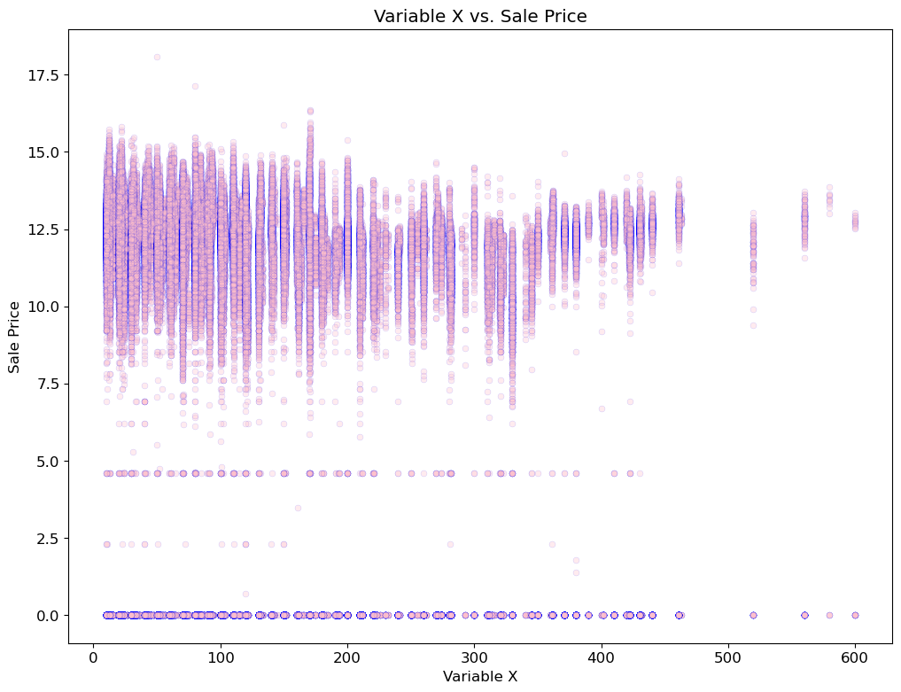

```python
plt.scatter(cook_data["Neighborhood Code"], np.log(cook_data['Sale Price']), s=25, alpha=0.3, color='pink', edgecolors='blue', linewidths=0.2 )
plt.xlabel('Variable X')
plt.ylabel('Sale Price')
plt.title('Variable X vs. Sale Price')
```

```python
grouped_by_hood = cook_data.groupby('Town and Neighborhood')['Sale Price'].mean().sort_values().reset_index().reset_index().drop('Sale Price', axis=1).rename(columns={'index': 'Neigborhood Rank'})

def rank_by_Neighborhood(data):
    return data.merge(grouped_by_hood, on='Town and Neighborhood', how='left')

rank_by_Neighborhood(cook_data)['Neigborhood Rank']
```

```
0         464
1         342
2          10
3         536
4          35
         ...
204787     51
204788    816
204789    212
204790    468
204791    206
Name: Neigborhood Rank, Length: 204792, dtype: int64
```

```python
grouped_by_hood
```

|  | Neigborhood Rank | Town and Neighborhood |
| --- | --- | --- |
| 0 | 0 | 72130 |
| 1 | 1 | 72171 |
| 2 | 2 | 1440 |
| 3 | 3 | 12111 |
| 4 | 4 | 70260 |
| ... | ... | ... |
| 826 | 826 | 7430 |
| 827 | 827 | 30100 |
| 828 | 828 | 2380 |
| 829 | 829 | 7422 |
| 830 | 830 | 23171 |

831 rows × 2 columns

```python
# Define any additional helper functions you need here


# Uncomment the line below to clean up memory from previous questions and reinitialize Otter!
# MAKE SURE TO COMMENT THE NEXT 3 LINES OUT BEFORE SUBMITTING!
# %reset -f
# import otter
# grader = otter.Notebook("proj1b.ipynb")

import numpy as np
import pandas as pd
from pandas.api.types import CategoricalDtype

%matplotlib inline
import matplotlib.pyplot as plt
import seaborn as sns
from sklearn import linear_model as lm

import warnings
warnings.filterwarnings("ignore")

import zipfile
import os

from ds100_utils import *
from feature_func import *
#...
#...

# Please include all of your feature engineering process inside this function.
# Do not modify the parameters of this function.


def process_data_fm(data, is_test_set=False):
    # Whenever you access 'Log Sale Price' or 'Sale Price', make sure to use the
    # condition is_test_set like this:
    if not is_test_set:
        # do your processing for the training set (i.e. not the test set)
        # this can involve references to sale price!
        data['Log Sale Price'] = np.log(data['Sale Price'])
        data = remove_outliers(data=data, variable='Sale Price', lower=800, upper=60000000)
        data = rank_by_Neighborhood(data)
        data = log_transform(data, col='Building Square Feet')
        data = data.loc[:, ['Log Sale Price', 'Neigborhood Rank', 'Building Square Feet']]

    else:
        data = rank_by_Neighborhood(data)
        data = log_transform(data, col='Building Square Feet')
        data = data.loc[:, ['Neigborhood Rank', 'Building Square Feet']]
        # do your processing for the test set
        # this CANNOT involve references to sale price!

    #...
    # Return predictors and response variables separately
    if is_test_set:
        X = data
        ... # any other processing you wish to do
        return X

    else:
        X = data.drop(['Log Sale Price'], axis = 1)
        y = data.loc[:, 'Log Sale Price']
        ... # any other processing you wish to do
        return X, y


check_rmse_threshold = run_linear_regression_test_optim(lm.LinearRegression(fit_intercept=True), process_data_fm, 'cook_county_train.csv', None, False)
print("Current training RMSE:", check_rmse_threshold.loss)
```

[output not shown]

## The Process

For building our last model, we tried to remove the outliers from the data set by using the log of the sale price, the building square feet and the town and neighborhood. This because we wanted to see if the outliers were affecting the model. To get to this point we attempted with different paramters until finding the ones that minimized the most.

In the context of estimating the value of houses, the error means that the model is not predicting the correct value of the house. This can affect the homeowner in terms of property taxes because the model is not predicting the correct value of the house. This can cause the homeowner to pay more (or less) taxes than they should.

In the case of the Cook County Assessor’s Office, Chief Data Officer Rob Ross states that fair property tax rates are contingent on whether property values are assessed accurately - that they’re valued at what they’re worth, relative to properties with similar characteristics. This implies that having a more accurate model results in fairer assessments. The goal of the property assessment process for the CCAO, then, is to be as accurate as possible.

When the use of algorithms and statistical modeling has real-world consequences, we often refer to the idea of fairness as a measurement of how socially responsible our work is. But fairness is incredibly multifaceted: Is a fair model one that minimizes loss - one that generates accurate results? Is it one that utilizes "unbiased" data? Or is fairness a broader goal that takes historical contexts into account?

These approaches to fairness are not mutually exclusive. If we look beyond error functions and technical measures of accuracy, we'd not only consider *individual* cases of fairness, but also what fairness - and justice - means to marginalized communities on a broader scale. We'd ask: What does it mean when homes in predominantly Black and Hispanic communities in Cook County are consistently overvalued, resulting in proportionally higher property taxes? When the white neighborhoods in Cook County are consistently undervalued, resulting in proportionally lower property taxes?

Having "accurate" predictions doesn't necessarily address larger historical trends and inequities, and fairness in property assessments in taxes works beyond the CCAO's valuation model. Disassociating accurate predictions from a fair system is vital to approaching justice at multiple levels. Take Evanston, IL - a suburb in Cook County - as an example of housing equity beyond just improving a property valuation model: Their City Council members [recently approved reparations for African American residents](https://www.usnews.com/news/health-news/articles/2021-03-23/chicago-suburb-approves-government-reparations-for-black-residents).

**In our own words:** Fairness in property assessments and taxes is when the model is predicting the correct value of the house, and the homeowner is paying the correct amount of taxes.